# R10_Project_Face_Detection_WIDER_DATASET-FINAL

Project Description - Face Detection || Points: 30 points

Project Description

In this hands-on project, the goal is to build a face detection model which includes building a face detector to locate the position of a face in an image.

Notebook & Dataset: WIDER Face Dataset

Pls access from the drive link below: https://drive.google.com/open?id=1AKTErkGaYjUfuhRJL8G1tCLkU5sVq2e5

WIDER FACE dataset is a face detection benchmark dataset, of which images are selected from the publicly available WIDER dataset.

This data have 32,203 images and 393,703 faces are labelled with a high degree of variability in scale, pose and occlusion as depicted in the sample images.

We will be using transfer learning on an already trained model to build our detector. We will perform transfer learning on Mobile Net model which is already trained to perform object detection. We will need to train the last 6-7 layers and freeze the remaining layers to train the model for face detection. To be able to train the Mobile Net model for face detection, we will be using WIDER FACE dataset which already has the bounding box data for various images with a single face and multiple faces. The output of the model is the bounding box data which gives the location of the face in an image. We learn to build a face detection model using Keras supported by Tensorflow.

Reference

Acknowledgement for the datasets. http://mmlab.ie.cuhk.edu.hk/projects/WIDERFace/ Mobile Net paper: https://arxiv.org/pdf/1704.04861.pdf

Overview

In this problem, we use "Transfer Learning" of an Object Detector model to detect any object according to the problem in hand.

Here, we are particularly interested in detecting faces in a given image. Below are the steps involved in the project.

Load the dataset given in form .npy format. Create Features(images) and labels(mask) using that data. Load the pre-trained model and weights. Create model using the above model. Define Dice Coefficient and Loss function. Compile and fit the model. Evaluate the model.

Instructions for all the above steps are given in the notebook.

## Load the dataset given in form .npy format.

```python
pip install cv2
```

[output not shown]

```python
import numpy as np
import pandas as pd
import cv2
wider=np.load('images.npy')
```

```python
wider.dtype
```

```
dtype('O')
```

```python
wider.dtype
```

```
dtype('O')
```

```python
wider.shape
```

```
(409, 2)
```

```python
print(wider.dtype)
```

```
object
```

```python
wider[4]
```

[output not shown]

```python
wider[0,1]
```

```
[{'label': ['Face'],
  'notes': '',
  'points': [{'x': 0.08615384615384615, 'y': 0.3063063063063063},
   {'x': 0.1723076923076923, 'y': 0.45345345345345345}],
  'imageWidth': 650,
  'imageHeight': 333},
 {'label': ['Face'],
  'notes': '',
  'points': [{'x': 0.583076923076923, 'y': 0.2912912912912913},
   {'x': 0.6584615384615384, 'y': 0.46846846846846846}],
  'imageWidth': 650,
  'imageHeight': 333}]
```

[figure not shown]

```python
#show sample images
from matplotlib import pyplot as plt
plt.imshow(wider[0][0])
```

```python
wider[0][0].shape
```

```
(333, 650, 3)
```

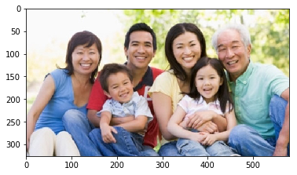

```python
#show sample images
plt.imshow(wider[4][0])
```

```python
wider[4][0].shape
```

```
(326, 580, 3)
```

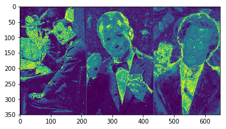

```python
#show sample images
plt.imshow(wider[272][0])
```

```python
wider[272][0].shape
```

```
(350, 650)
```

```python
# Checking to see for shape of images in wider dataset
for i in range(0,wider.shape[0]):
  try:
    if wider[i][0].shape[2]>3:
      print(i,wider[i][0].shape)
  except:
    print(i,wider[i][0].shape)
```

```
1 (697, 1280, 4)
3 (291, 600, 4)
41 (340, 516, 4)
49 (600, 800, 4)
64 (312, 750, 4)
140 (330, 538, 4)
151 (496, 860, 4)
247 (379, 505, 4)
263 (400, 770, 4)
272 (350, 650)
337 (267, 740, 4)
347 (281, 600, 4)
```

Observations

1. data has 409 images
2. data have 2 features, Images and label
3. dataset has images with 3 types of data with different channels ( height, width,3),( height, width) and ( height, width,4)

## Create Features(images) and labels(mask) using that data. Load the pre-trained model and weights.

```python
wider.shape
```

```
(409, 2)
```

```python
Data_set=[]
IMAGE_SIZE_Width=128
IMAGE_SIZE_Height=128
Data_set=[]
for j in range(0,wider.shape[0]):
  image_name='image_'+ str(j+1)
  for i in wider[j][1]:
    ori_Height=i['imageHeight']
    Ori_Width=i['imageWidth']
    label=i['label'][0]
    x1_ratio=i['points'][0]['x']
    x2_ratio=i['points'][1]['x']
    y1_ratio=i['points'][0]['y']
    y2_ratio=i['points'][1]['y']
    x1_ori=int((i['points'][0]['x'])*Ori_Width)
    x2_ori=int((i['points'][1]['x'])*Ori_Width)
    y1_ori=int((i['points'][0]['y'])*ori_Height)
    y2_ori=int((i['points'][1]['y'])*ori_Height)
    x_min=int((i['points'][0]['x'])*IMAGE_SIZE_Width)
    x_max=int((i['points'][1]['x'])*IMAGE_SIZE_Width)
    y_min=int((i['points'][0]['y'])*IMAGE_SIZE_Height)
    y_max=int((i['points'][1]['y'])*IMAGE_SIZE_Height)
    Data_set.append([image_name,ori_Height,Ori_Width,label,x1_ratio,x2_ratio,y1_ratio,y2_ratio,x1_ori,x2_ori,y1_ori,y2_ori,x_min,y_min,x_max,y_max])
```

```python
df=pd.DataFrame(Data_set,columns=['filename','ori_Height','Ori_Width','class','x1_ratio','x2_ratio','y1_ratio','y2_ratio','x1_ori','x2_ori','y1_ori','y2_ori','x_min','y_min','x_max','y_max'])
df.head()
```

|  | filename | ori_Height | Ori_Width | class | x1_ratio | x2_ratio | y1_ratio | y2_ratio | x1_ori | x2_ori | y1_ori | y2_ori | x_min | y_min | x_max | y_max |
| --- | --- | --- | --- | --- | --- | --- | --- | --- | --- | --- | --- | --- | --- | --- | --- | --- |
| 0 | image_1 | 333 | 650 | Face | 0.086154 | 0.172308 | 0.306306 | 0.453453 | 56 | 112 | 102 | 151 | 11 | 39 | 22 | 58 |
| 1 | image_1 | 333 | 650 | Face | 0.583077 | 0.658462 | 0.291291 | 0.468468 | 379 | 428 | 97 | 156 | 74 | 37 | 84 | 59 |
| 2 | image_2 | 697 | 1280 | Face | 0.705309 | 0.769231 | 0.232604 | 0.361829 | 902 | 984 | 162 | 252 | 90 | 29 | 98 | 46 |
| 3 | image_3 | 240 | 460 | Face | 0.469565 | 0.606522 | 0.050000 | 0.333333 | 216 | 279 | 12 | 80 | 60 | 6 | 77 | 42 |
| 4 | image_3 | 240 | 460 | Face | 0.628261 | 0.745652 | 0.008333 | 0.308333 | 289 | 343 | 2 | 74 | 80 | 1 | 95 | 39 |

```python
df.shape
```

```
(1132, 16)
```

```python
len(df['filename'].unique())
```

```
409
```

```python
print('# of classes in the wider dataset: ',len(df['class'].unique()))
```

```
# of classes in the wider dataset:  1
```

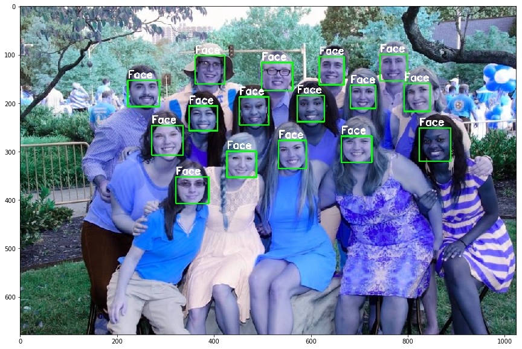

```python
#Pickup a random image number
img_num = np.random.randint(0, df.shape[0])
#img_num=5

#Read the image
img_file = df.loc[img_num,'filename']
img_loc=int(df.loc[img_num,'filename'].split('_')[1])-1
img = wider[img_loc][0]

#Find all rows which have same file name
rows_with_file = df[df['filename'] == img_file].index.tolist()

#Draw rectangle(s) as per bounding box information
for i in rows_with_file:

    #Get bounding box
    xmin, ymin, xmax, ymax = df.loc[i, ['x1_ori', 'y1_ori', 'x2_ori', 'y2_ori']]
    #Get Label
    label = df.loc[i, 'class']
    #Add bounding box
    cv2.rectangle(img, (xmin,ymin), (xmax, ymax), (0,255,0), 2)
    #Add text
    cv2.putText(img,label,(xmin, ymin-5),cv2.FONT_HERSHEY_SIMPLEX, 0.7, (255, 255, 255), 2)

#Convert BGR format (used by opencv to RGB format used by matplotlib)
img = cv2.cvtColor(img, cv2.COLOR_BGR2RGB)

#Draw image using matplotlib
plt.figure(figsize=(15,10))
plt.imshow(img)
plt.show()
```

## Load the pre-trained model and weights.

## Create model using the above model.

## Define Dice Coefficient and Loss function.

## Compile and fit the model.

```python
from keras.applications.mobilenet import preprocess_input
IMAGE_HEIGHT=128
IMAGE_WIDTH=128

#masks=np.zeros((int(img_array.shape[0]),IMAGE_HEIGHT,IMAGE_WIDTH))
masks=np.zeros((int(wider.shape[0]), 4))
X_train=np.zeros((int(wider.shape[0]),IMAGE_HEIGHT,IMAGE_WIDTH,3))
for index in range(wider.shape[0]):
  img=wider[index][0]
  img=cv2.resize(img, dsize=(IMAGE_HEIGHT,IMAGE_WIDTH),interpolation=cv2.INTER_CUBIC)
  try:
    img=img[:,:,:3]
  except:
    continue
  X_train[index]=preprocess_input(np.array(img,dtype=np.float32))
  masks[index,0] = x1_ori * IMAGE_WIDTH / Ori_Width
  masks[index,1] = y1_ori * IMAGE_HEIGHT / ori_Height
  masks[index,2] = x2_ori * IMAGE_WIDTH / Ori_Width
  masks[index,3] = y2_ori * IMAGE_HEIGHT / ori_Height
```

```python
display(X_train.shape, masks.shape)
```

```
(409, 128, 128, 3)
```

```
(409, 4)
```

```python
from PIL import Image
from keras_applications import mobilenet
from keras.applications.mobilenet import preprocess_input
from keras.backend import epsilon
from keras.models import Model
from keras.layers import Conv2D
from keras.layers import Reshape
```

```python
#The Dice coefficient is similar to the Jaccard Index (Intersection over Union, IoU)
def dice_loss(gt,pred):
    intersections = 0
    unions = 0
    diff_width = np.minimum(gt[:,0] + gt[:,2], pred[:,0] + pred[:,2]) - np.maximum(gt[:,0], pred[:,0])
    diff_height = np.minimum(gt[:,1] + gt[:,3], pred[:,1] + pred[:,3]) - np.maximum(gt[:,1], pred[:,1])
    intersection = diff_width * diff_height

    # Compute union
    area_gt = gt[:,2] * gt[:,3]
    area_pred = pred[:,2] * pred[:,3]
    union = area_gt + area_pred - intersection

#     Compute intersection and union over multiple boxes
    for j, _ in enumerate(union):
        if union[j] > 0 and intersection[j] > 0 and union[j] >= intersection[j]:
            intersections += intersection[j]
            unions += union[j]

    # Compute IOU. Use epsilon to prevent division by zero
    iou = np.round(intersections / (unions + epsilon()), 4)
    iou = iou.astype(np.float32)
    return iou

def IoU(y_true, y_pred):
    iou = tf.py_func(dice_loss, [y_true, y_pred], tf.float32)
    return iou
```

```python
from keras.applications.mobilenet import MobileNet
IMAGE_SIZE=128
IMG_SHAPE=(IMAGE_SIZE, IMAGE_SIZE, 3)
base_model = MobileNet(input_shape=IMG_SHAPE,include_top=False,alpha=1.0)
```

```
WARNING:tensorflow:From C:\Anaconda\lib\site-packages\tensorflow\python\framework\op_def_library.py:263: colocate_with (from tensorflow.python.framework.ops) is deprecated and will be removed in a future version.
Instructions for updating:
Colocations handled automatically by placer.
```

```python
base_model.trainable = True
```

```python
#Number of layers are in the base model
print("Number of layers in the base model: ", len(base_model.layers))
```

```
Number of layers in the base model:  87
```

```python
# Fine-tune from this layer onwards
fine_tune_at = len(base_model.layers)-6

# Freeze all the layers before the `fine_tune_at` layer
for layer in base_model.layers[:fine_tune_at]:
  layer.trainable =  False
```

```python
base_model.summary()
```

```
Model: "mobilenet_1.00_128"
_________________________________________________________________
Layer (type)                 Output Shape              Param #
=================================================================
input_1 (InputLayer)         (None, 128, 128, 3)       0
_________________________________________________________________
conv1_pad (ZeroPadding2D)    (None, 129, 129, 3)       0
_________________________________________________________________
conv1 (Conv2D)               (None, 64, 64, 32)        864
_________________________________________________________________
conv1_bn (BatchNormalization (None, 64, 64, 32)        128
_________________________________________________________________
conv1_relu (ReLU)            (None, 64, 64, 32)        0
_________________________________________________________________
conv_dw_1 (DepthwiseConv2D)  (None, 64, 64, 32)        288
_________________________________________________________________
conv_dw_1_bn (BatchNormaliza (None, 64, 64, 32)        128
_________________________________________________________________
conv_dw_1_relu (ReLU)        (None, 64, 64, 32)        0
_________________________________________________________________
conv_pw_1 (Conv2D)           (None, 64, 64, 64)        2048
_________________________________________________________________
conv_pw_1_bn (BatchNormaliza (None, 64, 64, 64)        256
_________________________________________________________________
conv_pw_1_relu (ReLU)        (None, 64, 64, 64)        0
_________________________________________________________________
conv_pad_2 (ZeroPadding2D)   (None, 65, 65, 64)        0
_________________________________________________________________
conv_dw_2 (DepthwiseConv2D)  (None, 32, 32, 64)        576
_________________________________________________________________
conv_dw_2_bn (BatchNormaliza (None, 32, 32, 64)        256
_________________________________________________________________
conv_dw_2_relu (ReLU)        (None, 32, 32, 64)        0
_________________________________________________________________
conv_pw_2 (Conv2D)           (None, 32, 32, 128)       8192
_________________________________________________________________
conv_pw_2_bn (BatchNormaliza (None, 32, 32, 128)       512
_________________________________________________________________
conv_pw_2_relu (ReLU)        (None, 32, 32, 128)       0
_________________________________________________________________
```

[output cut: 127 more lines]

```
_________________________________________________________________
conv_dw_13_bn (BatchNormaliz (None, 4, 4, 1024)        4096
_________________________________________________________________
conv_dw_13_relu (ReLU)       (None, 4, 4, 1024)        0
_________________________________________________________________
conv_pw_13 (Conv2D)          (None, 4, 4, 1024)        1048576
_________________________________________________________________
conv_pw_13_bn (BatchNormaliz (None, 4, 4, 1024)        4096
_________________________________________________________________
conv_pw_13_relu (ReLU)       (None, 4, 4, 1024)        0
=================================================================
Total params: 3,228,864
Trainable params: 1,061,888
Non-trainable params: 2,166,976
_________________________________________________________________
```

```python
X=base_model.layers[fine_tune_at].output
X=Conv2D(4,kernel_size=4)(X)
X=Reshape((4,))(X)
```

```python
base_model=Model(inputs=base_model.input, output=X)
```

```python
import tensorflow as tf
base_model.compile(optimizer='adam',loss='mse',metrics=[IoU])
```

[output not shown]

```python
base_model.fit(X_train,masks,epochs=30,batch_size=32,verbose=1)
```

```
WARNING:tensorflow:From C:\Anaconda\lib\site-packages\tensorflow\python\ops\math_ops.py:3066: to_int32 (from tensorflow.python.ops.math_ops) is deprecated and will be removed in a future version.
Instructions for updating:
Use tf.cast instead.
```

```
<keras.callbacks.History at 0x25535164c50>
```

```python
base_model.save('face_wider_dataset_detect_final.h5')
```

## Evaluate the model.

```python
import cv2
```

```python
#read image
r1=cv2.imread('C:\\Users\\Hema\\Desktop\\1_VH_AIML\\1 Assignments\\Project1 ACV WIDER data 31JAN FACE DETECTION\\PEOPLE.jpg')
#r1=cv2.imread('C:\\Users\\Hema\\Desktop\\1_VH_AIML\\1 Assignments\\Project1 ACV WIDER data 31JAN FACE DETECTION\\baby1.jfif')
r1
```

[output not shown]

```python
masks = np.zeros((int(r1.shape[0]), IMAGE_HEIGHT, IMAGE_WIDTH))
```

```python
masks.shape
```

```
(225, 128, 128)
```

```python
r1.shape
```

```
(225, 225, 3)
```

```python
image_height,image_width,_=r1.shape
```

```python
image_height
```

```
225
```

```python
image_width
```

```
225
```

### Resize the image to 128 * 128 and preprocess the image for the MobileNet model

```python
r2=cv2.resize(r1,(IMAGE_SIZE,IMAGE_SIZE))
```

```python
r2.shape
```

```
(128, 128, 3)
```

```python
#unscaled image
r2
```

[output not shown]

### Predict the coordinates of the bounding box for the given test image

```python
#scaled image
r2_pp=preprocess_input(np.array(r2,dtype=np.float32))
```

```python
r2_pp
```

[output not shown]

```python
region = base_model.predict(np.array([r2_pp]))[0]
```

```python
region
```

```
array([102.68321 ,  65.509575, 108.68517 ,  81.5393  ], dtype=float32)
```

### Plot the test image using .imshow and draw a boundary box around the image with the coordinates obtained from the model

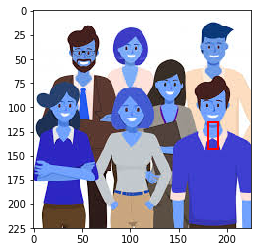

```python
x0 = int(region[0] * image_width / IMAGE_SIZE) # Scale the BBox
y0 = int(region[1] * image_height / IMAGE_SIZE)

x1 = int((region[2]) * image_width / IMAGE_SIZE)
y1 = int((region[3]) * image_height / IMAGE_SIZE)


import matplotlib.pyplot as plt
import matplotlib.patches as patches
from PIL import Image
import numpy as np


# Create figure and axes
fig,ax = plt.subplots(1)

# Display the image
ax.imshow(r1)

# Create a Rectangle patch
rect = patches.Rectangle((x0, y0), (x1 - x0) , (y1 - y0) , linewidth=2, edgecolor='r', facecolor='none')

# Add the patch to the Axes
ax.add_patch(rect)

plt.show()
```